# Análisis de Datos I Tarea 12

# Librerías

```r
library(dplyr)
library(traineR)
library(MASS)
library(caret)
library(kableExtra)
```

# Pregunta 1

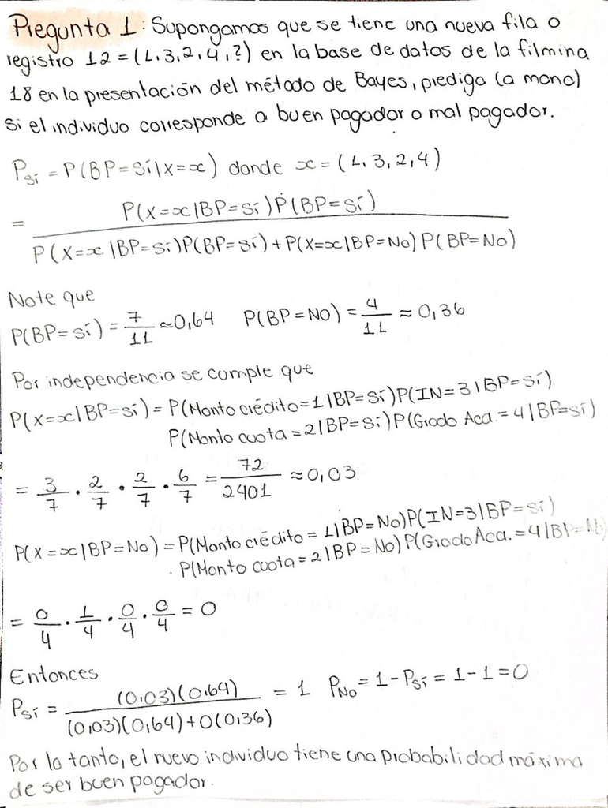

# Pregunta 2

[figure not shown]

# Pregunta 3

En esta pregunta utiliza los datos (tumores.csv). Se trata de un conjunto de datos de características del tumor cerebral que incluye cinco variables de primer orden y ocho de textura y cuatro parámetros de evaluación de la calidad con el nivel objetivo. La variables son: Media, Varianza, Desviación estándar, Asimetría, Kurtosis, Contraste, Energía, ASM (segundo momento angular), Entropía, Homogeneidad, Disimilitud, Correlación, Grosor, PSNR (Pico de la relaci´on señal-ruido), SSIM (Índice de Similitud Estructurada), MSE (Mean Square Error), DC (Coeficiente de Dados) y la variable a predecir tipo (1 = Tumor, 0 = No-Tumor). Realice lo siguiente:

## 1. Cargue la tabla de datos tumores.csv en R y genere en R usando la función createDataPartition(…) del paquete caret la tabla de testing con una 25 % de los datos y con el resto de los datos genere una tabla de aprendizaje.

```r
set.seed(12)
```

```r
datos_tumores <- read.csv("tumores.csv", header = TRUE, sep = ",", dec = ".")
datos_tumores$tipo <- as.factor(datos_tumores$tipo)

muestra <- createDataPartition(y = datos_tumores$tipo, p = 0.75, list = F)
tabla_testing <- datos_tumores[-muestra,]
tabla_aprendizaje <- datos_tumores[muestra,]
tabla_testing <- tabla_testing[,-1]
tabla_aprendizaje <- tabla_aprendizaje[,-1]
```

## 2. Usando Naive Bayes, LDA y QDA genere modelos predictivos para la tabla de aprendizaje, puede ser que LDA y QDA generen errores.

### Naive Bayes

```r
modelo_bayes <- train.bayes(tipo~., data = tabla_aprendizaje)
prediccion_bayes <- predict(modelo_bayes, tabla_testing, type = "class")
```

### LDA

```r
modelo_LDA <- train.lda(tipo~., data=tabla_aprendizaje)
prediccion_LDA <- predict(modelo_LDA, tabla_testing)
```

### QDA

Como QDA genera errores se va a incluir un ruido en los valores de la tabla de aprendizaje.

```r
valores <- matrix(runif(n = nrow(tabla_aprendizaje[,-17]) * ncol(tabla_aprendizaje[,-17]),
                        min = 0, max = 0.01),
                  nrow = nrow(tabla_aprendizaje[,-17]), ncol = ncol(tabla_aprendizaje[,-17]))
tabla_aprendizaje_valores <- tabla_aprendizaje[,-17] + valores
tabla_aprendizaje_valores <- cbind(tabla_aprendizaje_valores, tipo = tabla_aprendizaje[,17])
```

Se genera el modelo con la nueva tabla de aprendizaje.

```r
modelo_QDA <- train.qda(tipo~., data=tabla_aprendizaje_valores)
prediccion_QDA <- predict(modelo_QDA, tabla_testing)
```

## 3. Para la tabla de testing calcule la matriz de confusión, la precisión global, el error global y la precisión en cada de las clases. Construya una tabla para los índices anteriores que permita comparar los resultados de Naive Bayes, LDA y QDA con respecto a los métodos generados en las tareas anteriores. ¿Cuál método es mejor?

### Naive Bayes

```r
matriz_confusion_bayes <- confusion.matrix(tabla_testing, prediccion_bayes)
general.indexes(mc = matriz_confusion_bayes)
```

```
##
## Confusion Matrix:
##     prediction
## real   0   1
##    0  14  10
##    1  24 270
##
## Overall Accuracy: 0.8931
## Overall Error:    0.1069
##
## Category Accuracy:
##
##             0            1
##      0.583333     0.918367
```

### LDA

```r
matriz_confusion_LDA <- confusion.matrix(tabla_testing, prediccion_LDA)
general.indexes(mc = matriz_confusion_LDA)
```

```
##
## Confusion Matrix:
##     prediction
## real   0   1
##    0  21   3
##    1  14 280
##
## Overall Accuracy: 0.9465
## Overall Error:    0.0535
##
## Category Accuracy:
##
##             0            1
##      0.875000     0.952381
```

### QDA

```r
matriz_confusion_QDA <- confusion.matrix(tabla_testing, prediccion_QDA)
general.indexes(mc = matriz_confusion_QDA)
```

```
##
## Confusion Matrix:
##     prediction
## real   0   1
##    0  16   8
##    1   7 287
##
## Overall Accuracy: 0.9528
## Overall Error:    0.0472
##
## Category Accuracy:
##
##             0            1
##      0.666667     0.976190
```

### KNN

De los métodos de las tareas anteriores se tiene el metodo de K vecinos más cercanos (KNN).

```r
modelo_KNN <- train.knn(tipo~., data = tabla_aprendizaje,
                        kmax = floor(sqrt(nrow(tabla_aprendizaje))))
prediccion_KNN <- predict(modelo_KNN, tabla_testing, type = "class")
matriz_confusion_KNN <- confusion.matrix(tabla_testing, prediccion_KNN)
general.indexes(mc = matriz_confusion_KNN)
```

```
##
## Confusion Matrix:
##     prediction
## real   0   1
##    0  16   8
##    1   2 292
##
## Overall Accuracy: 0.9686
## Overall Error:    0.0314
##
## Category Accuracy:
##
##             0            1
##      0.666667     0.993197
```

### Tabla de índices

[output not shown]

El mejor método depende de los resultados que se están deseando, sin embargo, al guiarse con estos índices se puede ver que el que tiene mayor precisión global, mayor precisión para detectar los casos en los que la persona sí tiene tumor y a su vez un menor error global es el método de K vecinos más cercanos.

# Ejercicio 4

**Teorema (Regla de Asignación)**  
*El Análisis Discriminante asigna $X = x$ a la clase con mayor $\delta_{k}(x)$ donde:*

$$\delta_{k}(x) = x \cdot
\dfrac{\mu_{k}}{\sigma^{2}} - \dfrac{\mu_{k}^{2}}{2 \sigma^{2}} +
\log(\pi_{k})$$

**Prueba:**

Note que de fondo, $\delta_{k}(x)$ se trata de una densidad posterior, y por lo tanto se procede de la siguiente forma:

$$p_{k}(x) \propto \pi_{k}
\dfrac{1}{\sqrt{2 \pi} \sigma} e^{\left(-\frac{1}{2 \sigma^{2}}(x-
\mu_{k})^{2}\right)}$$

De acá se obtetiene que:

$$\begin{align*}
\delta_{k}(x) &\propto \ln(p_{k}(x))\\\\
&\propto \ln\left(\pi_{k} \dfrac{1}{\sqrt{2 \pi} \sigma}
e^{\left(-\frac{1}{2 \sigma^{2}}(x- \mu_{k})^{2} \right)}\right)\\\\
&\propto \ln(\pi_{k}) + \ln\left(\dfrac{1}{\sqrt{2 \pi}
\sigma}\right) + \ln\left(e^{\left(-\frac{1}{2 \sigma^{2}}(x-
\mu_{k})^{2} \right)}\right)\\\\
&\propto \ln(\pi_{k}) - \dfrac{1}{2} \ln(2 \pi \sigma^{2}) -
\frac{1}{2 \sigma^{2}}(x- \mu_{k})^{2}\\\\
&\propto \ln(\pi_{k}) - \dfrac{1}{2} \ln(2 \pi \sigma^{2}) -
\frac{1}{2 \sigma^{2}}(x^{2}- 2x \mu_{k} + \mu_{k}^{2})\\\\
&\propto \ln(\pi_{k}) - \dfrac{1}{2} \ln(2 \pi \sigma^{2}) -
\frac{x^{2}}{2 \sigma^{2}} + \frac{2x \mu_{k}}{2 \sigma^{2}} -
\frac{\mu_{k}^{2}}{2 \sigma^{2}}
\end{align*}$$

Ahora, es importante notar que acá la variable no es $x$, sino $k$, pues se está buscando, dado $X = x$ a cual $k$ clase pertenece $x$. Por lo tanto, en la ecuación anterior, tanto $\frac{1}{2} \ln(2 \pi \sigma^{2})$ como $\frac{x^{2}}{2 \sigma^{2}}$ se agregan a la constante de proporcionalidad, por lo que al final se obtiene la formula deseada:

$$\delta_{k}(x) = x \cdot
\frac{\mu_{k}}{\sigma^{2}} - \frac{\mu_{k}^{2}}{2 \sigma^{2}} +
\ln(\pi_{k})$$

**Ejemplo 1**  
*Si $k=2$ y $\pi_{1} = \pi_{2}$ entonces el Análisis Discriminante asigna la observación (individuo) $X=x$ a la clase 1 si:*

$$2x(\mu_{1} -\mu_{2}) > \mu_{1}^{2} -
\mu_{2}^{2}$$

*y la clase 2 en otro caso.*

**Prueba:**

Observe que del teorema anterior se puede concluir que si se asigna $x$ a la clase 1, entonces $delta_{1}(x) > delta_{2}(x)$ lo cual implica que, dado $\pi_{1} = \pi_{2}$, se tiene que cumplir que:

$$\begin{align*}
\delta_{1}(x) > \delta_{2}(x) &\Leftrightarrow x \cdot
\frac{\mu_{1}}{\sigma^{2}} - \frac{\mu_{1}^{2}}{2 \sigma^{2}} +
\ln(\pi_{1}) > x \cdot \frac{\mu_{2}}{\sigma^{2}} -
\frac{\mu_{2}^{2}}{2 \sigma^{2}} + \ln(\pi_{2})\\\\
&\Leftrightarrow x \cdot \frac{\mu_{1}}{\sigma^{2}} -
\frac{\mu_{1}^{2}}{2 \sigma^{2}} + \ln(\pi_{1}) > x \cdot
\frac{\mu_{2}}{\sigma^{2}} - \frac{\mu_{2}^{2}}{2 \sigma^{2}} +
\ln(\pi_{1})\\\\
&\Leftrightarrow x \cdot \mu_{1} - x \cdot \mu_{2} >
\frac{\mu_{1}^{2}}{2} - \frac{\mu_{2}^{2}}{2}\\\\
&\Leftrightarrow 2x(\mu_{1} - \mu_{2}) > \mu_{1}^{2} -
\mu_{2}^{2}\\\\
\end{align*}$$

Por lo tanto se cumple la condición a probar.

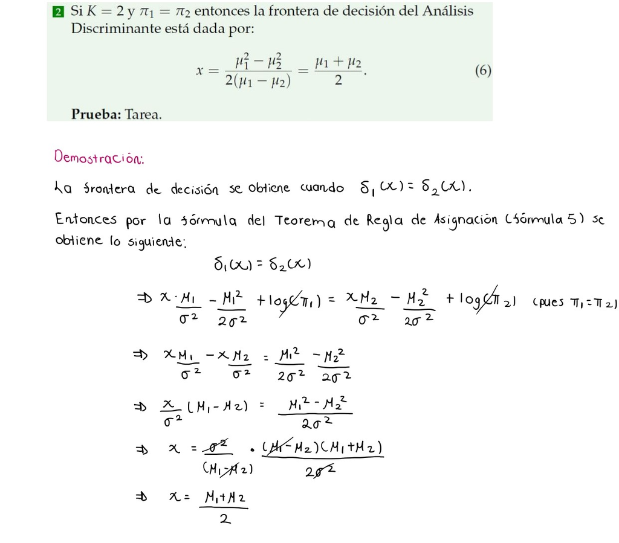

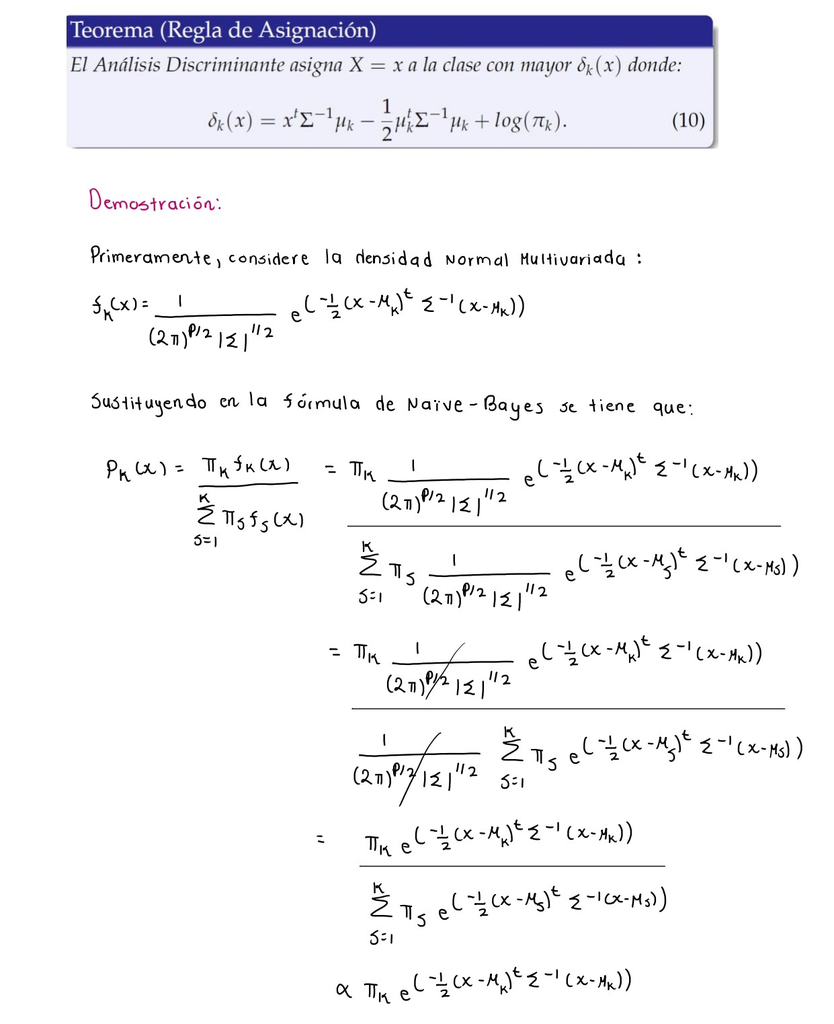

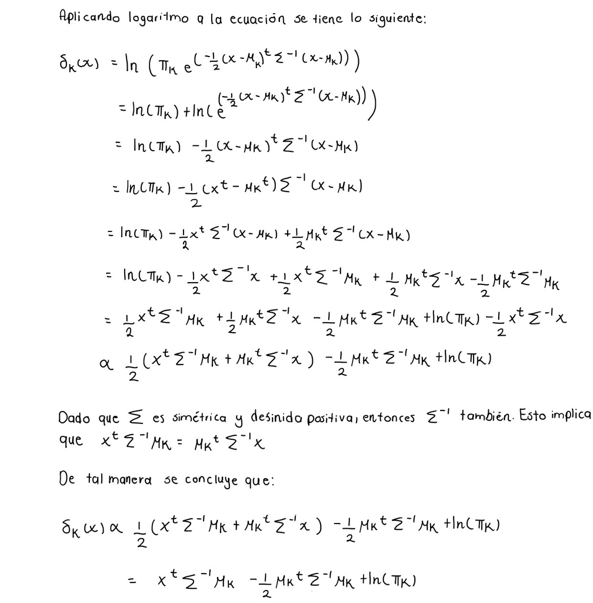

# Ejercicio 5

**1. Cargue la tabla de datos titanicV2024.csv, asegúrese de re-codificar las variables cualitativas y de ignorar variables que no se deben usar**

Se carga la base de datos.

```r
titanic_datos <- read.csv("titanicV2024.csv", header = TRUE, sep = ",", dec = ".")
kable_styling(kable(head(titanic_datos)))
```

| PassengerId | Survived | Pclass | Name | Sex | Age | SibSp | Parch | Ticket | Fare | Cabin | Embarked |
| --- | --- | --- | --- | --- | --- | --- | --- | --- | --- | --- | --- |
| 1 | 0 | 3 | Braund, Mr. Owen Harris | male | 22 | 1 | 0 | A/5 21171 | 7.2500 | NA | S |
| 2 | 1 | 1 | Cumings, Mrs. John Bradley (Florence Briggs Thayer) | female | 38 | 1 | 0 | PC 17599 | 71.2833 | C85 | C |
| 3 | 1 | 3 | Heikkinen, Miss. Laina | female | 26 | 0 | 0 | STON/O2. 3101282 | 7.9250 | NA | S |
| 4 | 1 | 1 | Futrelle, Mrs. Jacques Heath (Lily May Peel) | female | 35 | 1 | 0 | 113803 | 53.1000 | C123 | S |
| 5 | 0 | 3 | Allen, Mr. William Henry | male | 35 | 0 | 0 | 373450 | 8.0500 | NA | S |
| 6 | 0 | 3 | Moran, Mr. James | male | NA | 0 | 0 | 330877 | 8.4583 | NA | Q |

Se eliminan las variables Passengerid, Name, Ticket y Cabin, pues, son valores únicos implicando que la cantidad de cantegorías por variables sean demasiadas, lo cual, resta precisión.

```r
titanic_datos <- titanic_datos[, -c(1,4,9,11)]
```

Se re-codifican las variables cualitativas para que sean de tipo factor.

```r
titanic_datos <- titanic_datos %>%
   mutate(Survived =  as.factor(Survived),
          Pclass =  as.factor(Pclass),
          Sex =  as.factor(Sex),
          Embarked =  as.factor(Embarked))
str(titanic_datos)
```

```
## 'data.frame':    1309 obs. of  8 variables:
##  $ Survived: Factor w/ 2 levels "0","1": 1 2 2 2 1 1 1 1 2 2 ...
##  $ Pclass  : Factor w/ 3 levels "1","2","3": 3 1 3 1 3 3 1 3 3 2 ...
##  $ Sex     : Factor w/ 2 levels "female","male": 2 1 1 1 2 2 2 2 1 1 ...
##  $ Age     : num  22 38 26 35 35 NA 54 2 27 14 ...
##  $ SibSp   : int  1 1 0 1 0 0 0 3 0 1 ...
##  $ Parch   : int  0 0 0 0 0 0 0 1 2 0 ...
##  $ Fare    : num  7.25 71.28 7.92 53.1 8.05 ...
##  $ Embarked: Factor w/ 3 levels "C","Q","S": 3 1 3 3 3 2 3 3 3 1 ...
```

Se identican la cantidad de NA’s presentes en cada variable.

```r
na_variables <- colSums(is.na(titanic_datos))
print(na_variables)
```

```
## Survived   Pclass      Sex      Age    SibSp    Parch     Fare Embarked
##        0        0        0      263        0        0        1        2
```

De acuerdo con los mostrado, la variable Age cuenta con datos faltantes. Por tal motivo, se procede a rellenarlos con el promedio de las edades según el sexo.

```r
# Se filtran las edades
mujeres_edades <- na.omit(titanic_datos$Age[titanic_datos$Sex == "female"])
hombres_edades <- na.omit(titanic_datos$Age[titanic_datos$Sex == "male"])

# Se calculan los promedios de las edades
edad_promedio_mujeres <- round(mean(mujeres_edades))
edad_promedio_hombres <- round(mean(hombres_edades))

# Se rellenan los datos faltantes
titanic_datos$Age[titanic_datos$Sex == "female" & is.na(titanic_datos$Age)] <- edad_promedio_mujeres
titanic_datos$Age[titanic_datos$Sex == "male" & is.na(titanic_datos$Age)] <- edad_promedio_hombres
```

También, la variable Embarked presenta dos variables faltantes. Se rellenan con la moda de las cateogrías.

```r
# Se obtiene la moda para la variable Embarked
tabla_frec <- table(titanic_datos$Embarked)  # Se calcula la tabla de frecuencias
moda  <- names(tabla_frec)[which.max(tabla_frec)]  # Encontrar el valor con la frecuencia más alta

# Se rellena el dato faltante
titanic_datos$Embarked[is.na(titanic_datos$Embarked)] <- moda
```

Finalmente, el dato faltante en Fare se rellena con el promedio de las tarifas según el tipo de clase en que viajaba.

```r
# Se identifica la clase en que viajaba
clase <- titanic_datos$Pclass[is.na(titanic_datos$Fare)]

# Se filtran las tarifas según el tipo de clase de viaje
tarifas <- na.omit(titanic_datos$Fare[titanic_datos$Pclass == clase])

# Se obtiene el promedio de las tarifas
tarifa_promedio <- mean(tarifas)

# Se rellena el dato faltante
titanic_datos$Fare[is.na(titanic_datos$Fare)] <- tarifa_promedio
```

```r
set.seed(2529) # se siembra una semilla para la reproducibilidad

n <- nrow(titanic_datos)
muestra_titanic <- sample(1:n, floor(n*0.20))
```

Con esa muestra se obtienen las particiones en tabla de aprendizaje y testing.

```r
taprendizaje_titanic <- titanic_datos[muestra_titanic, ]
ttesting_titanic     <- titanic_datos[-muestra_titanic, ]

kable_styling(kable(head(taprendizaje_titanic)))
```

|  | Survived | Pclass | Sex | Age | SibSp | Parch | Fare | Embarked |
| --- | --- | --- | --- | --- | --- | --- | --- | --- |
| 329 | 1 | 3 | female | 31.0 | 1 | 1 | 20.5250 | S |
| 1138 | 1 | 2 | female | 22.0 | 0 | 0 | 21.0000 | S |
| 638 | 0 | 2 | male | 31.0 | 1 | 1 | 26.2500 | S |
| 450 | 1 | 1 | male | 52.0 | 0 | 0 | 30.5000 | S |
| 1120 | 0 | 3 | male | 40.5 | 0 | 0 | 15.1000 | S |
| 137 | 1 | 1 | female | 19.0 | 0 | 2 | 26.2833 | S |

```r
kable_styling(kable(head(ttesting_titanic)))
```

|  | Survived | Pclass | Sex | Age | SibSp | Parch | Fare | Embarked |
| --- | --- | --- | --- | --- | --- | --- | --- | --- |
| 2 | 1 | 1 | female | 38 | 1 | 0 | 71.2833 | C |
| 3 | 1 | 3 | female | 26 | 0 | 0 | 7.9250 | S |
| 4 | 1 | 1 | female | 35 | 1 | 0 | 53.1000 | S |
| 5 | 0 | 3 | male | 35 | 0 | 0 | 8.0500 | S |
| 6 | 0 | 3 | male | 31 | 0 | 0 | 8.4583 | Q |
| 7 | 0 | 1 | male | 54 | 0 | 0 | 51.8625 | S |

**3. Genere un Modelo Predictivo usando Naïve Bayes, con el paquete traineR, luego para este modelo calcule la matriz de confusión, la precisión, la precisión positiva, la precisión negativa, los falsos positivos, los falsos negativos, la acertividad positiva y la acertividad negativa.**

Se realiza el modelo predictivo mediante el Naïve Bayes:

```r
modelo_titanic_bayes <- train.bayes(Survived~., data = taprendizaje_titanic)
modelo_titanic_bayes
```

```
##
## Naive Bayes Classifier for Discrete Predictors
##
## Call:
## naiveBayes.default(x = X, y = Y, laplace = laplace)
##
## A-priori probabilities:
## Y
##         0         1
## 0.5747126 0.4252874
##
## Conditional probabilities:
##    Pclass
## Y           1         2         3
##   0 0.1600000 0.2066667 0.6333333
##   1 0.3153153 0.2432432 0.4414414
##
##    Sex
## Y      female      male
##   0 0.1000000 0.9000000
##   1 0.8288288 0.1711712
##
##    Age
## Y       [,1]     [,2]
##   0 30.14553 12.80277
##   1 28.98649 12.28940
##
##    SibSp
## Y        [,1]      [,2]
##   0 0.5400000 1.1622127
##   1 0.4504505 0.8172986
##
##    Parch
## Y        [,1]      [,2]
##   0 0.2866667 0.6381250
##   1 0.4594595 0.7358827
##
##    Fare
## Y       [,1]     [,2]
##   0 25.93982 39.77736
##   1 46.10969 62.67029
##
##    Embarked
## Y           C         Q         S
##   0 0.2066667 0.0600000 0.7333333
##   1 0.1981982 0.1441441 0.6576577
```

Luego, se obtienen las predicciones del modelo:

```r
prediccion_titanic <- predict(modelo_titanic_bayes, ttesting_titanic, type = "class")
prediccion_titanic$prediction
```

```
##    [1] 1 1 1 0 0 0 0 1 1 1 1 0 1 1 0 0 1 0 1 0 0 1 0 1 0 0 1 1 0 0 0 0 0 1 1 1 0
##   [38] 1 0 1 0 0 1 1 0 1 0 1 0 1 0 0 1 0 0 0 0 0 0 0 0 0 0 1 0 1 0 1 0 1 1 0 0 0
##   [75] 0 0 0 0 0 1 0 0 0 0 1 0 0 1 0 1 0 1 1 0 0 1 0 0 0 0 0 0 0 0 0 1 1 0 0 0 0
##  [112] 0 1 0 0 0 1 0 0 0 0 0 0 0 0 0 0 1 0 0 0 0 1 1 0 0 0 0 1 0 0 0 1 0 0 0 0 0
##  [149] 0 0 1 0 1 1 0 0 0 0 0 0 1 0 0 1 0 1 0 0 0 1 0 0 0 0 0 0 0 0 0 0 1 0 0 0 1
##  [186] 0 1 0 0 1 1 0 0 0 0 1 0 0 1 0 0 1 1 1 1 0 0 1 0 0 0 1 1 0 1 0 1 1 1 0 0 0
##  [223] 0 0 0 0 0 0 1 1 1 0 1 0 0 0 1 0 1 1 0 0 1 0 1 1 1 0 1 1 1 0 0 1 1 0 1 1 0
##  [260] 0 1 1 1 0 1 1 1 0 1 0 0 0 1 0 0 1 1 0 0 0 0 0 0 1 1 1 1 0 1 0 0 1 1 1 1 0
##  [297] 0 0 1 1 0 0 1 0 1 0 0 1 1 0 0 1 1 0 1 0 0 1 0 0 0 1 0 0 0 0 0 0 1 0 1 1 0
##  [334] 1 0 0 0 1 0 1 0 0 0 0 0 1 1 1 1 1 0 0 1 1 1 0 1 0 0 0 0 0 0 1 1 0 0 0 0 0
##  [371] 0 0 0 1 0 1 1 0 0 0 1 0 0 0 1 0 0 1 0 0 0 0 0 0 0 0 1 0 0 1 1 1 0 1 0 0 0
##  [408] 0 0 0 1 0 0 1 1 0 0 1 0 1 1 0 1 0 0 1 1 0 1 0 1 1 0 0 0 0 1 0 0 0 1 0 0 0
##  [445] 0 1 1 1 0 0 0 0 1 0 0 0 1 0 0 0 1 1 1 0 1 1 0 0 1 0 0 0 0 1 0 0 0 1 0 0 0
##  [482] 1 0 0 0 0 0 0 0 1 1 1 0 1 0 0 0 1 0 0 0 0 0 0 0 0 1 0 0 0 0 0 1 0 0 1 0 0
##  [519] 1 0 0 0 0 0 1 0 1 0 0 1 0 0 0 0 0 0 0 0 0 0 1 1 0 0 0 0 0 1 1 1 1 0 0 0 0
##  [556] 0 0 0 0 1 0 1 0 0 0 0 0 1 0 1 0 1 0 0 0 0 0 1 0 0 0 0 1 1 0 0 0 0 0 0 0 0
##  [593] 0 1 1 0 0 0 1 1 0 0 0 1 0 0 0 0 1 0 0 1 0 0 1 0 0 0 0 1 0 0 0 1 0 1 0 0 1
##  [630] 1 0 0 1 0 1 0 0 0 0 1 0 0 0 0 0 0 0 0 1 1 0 1 0 1 1 0 0 0 0 1 0 0 0 0 0 0
##  [667] 0 1 0 0 0 0 0 0 0 1 1 0 0 1 0 0 0 0 1 0 0 0 0 1 0 0 1 1 1 1 0 1 0 0 1 0 0
##  [704] 1 1 0 0 0 1 0 0 1 0 1 0 1 0 1 0 0 0 1 1 0 1 1 0 0 1 0 1 1 0 0 1 1 0 0 1 0
##  [741] 0 1 0 0 0 0 1 0 1 0 0 0 0 0 1 0 0 1 1 0 0 0 0 0 0 0 0 0 0 1 1 1 0 1 1 0 0
##  [778] 1 1 0 0 1 0 1 0 0 0 0 1 1 1 0 1 0 1 0 0 1 0 1 1 0 0 0 1 0 0 0 0 0 0 1 1 1
##  [815] 1 0 0 1 0 1 1 0 1 0 0 1 0 0 0 0 1 0 0 0 0 1 1 1 0 0 0 0 0 1 0 1 0 0 1 0 1
##  [852] 0 0 1 0 1 0 0 0 1 1 1 0 1 1 0 0 1 0 1 1 0 0 0 0 0 0 0 0 1 0 1 0 1 0 0 0 1
##  [889] 0 0 1 0 0 1 1 1 0 0 1 1 0 1 0 1 0 0 0 0 1 1 1 1 1 0 0 0 1 1 1 0 1 0 0 0 0
##  [926] 0 0 1 1 0 0 0 1 0 0 0 1 0 1 0 0 0 0 1 0 1 1 0 0 0 0 0 0 1 0 0 0 1 0 0 0 0
##  [963] 0 1 1 1 0 1 0 1 1 0 0 0 0 0 1 0 0 0 1 0 0 1 0 0 0 0 0 0 1 1 0 1 0 1 0 1 0
## [1000] 0 0 1 0 1 0 1 0 1 0 1 0 1 0 0 1 0 0 1 0 0 0 0 0 0 1 1 0 0 0 1 1 0 1 0 1 0
## [1037] 0 0 0 1 1 1 1 1 0 0 0 0
## Levels: 0 1
```

Se calcula la matriz de confusión que permite identificar la información de las predicciones dada por el modelo y comparar con los datos reales.

```r
matriz_confusion_titanic <- confusion.matrix(ttesting_titanic, prediccion_titanic)
matriz_confusion_titanic
```

```
##     prediction
## real   0   1
##    0 591  74
##    1  89 294
```

Para obtener los índices de calidad del modelo, se crea una función que devuelve una lista con los resultados.

```r
indices_matriz <- function(matriz_confusion){
  VN <- matriz_confusion[1,1]
  FP <- matriz_confusion[1,2]
  FN <- matriz_confusion[2,1]
  VP <- matriz_confusion[2,2]

  P <- (VN+VP)/sum(matriz_confusion)
  E <- (FP+FN)/sum(matriz_confusion)
  PP <- VP/(FN+VP)
  PN <- VN/(VN+FP)
  PFP <- FP/(VN+FP)
  PFN <- FN/(FN+VP)
  AP <- VP/(FP+VP)
  AN <- VN/(VN+FN)

  indices <- list(
    'Precision Global' = P,
    'Error Global' = E,
    'Precisión Positiva' = PP,
    'Precisión Negativa' = PN,
    'Proporción de Falsos Positivos' = PFP,
    'Proporción de Falsos Negativos' = PFN,
    'Asertividad Positiva' = AP,
    'Asertividad Negativa' = AN
  )

  return(indices)
}
```

```r
ind_modelo_bayes <- indices_matriz(matriz_confusion_titanic)
ind_modelo_bayes
```

```
## $`Precision Global`
## [1] 0.8444656
##
## $`Error Global`
## [1] 0.1555344
##
## $`Precisión Positiva`
## [1] 0.767624
##
## $`Precisión Negativa`
## [1] 0.8887218
##
## $`Proporción de Falsos Positivos`
## [1] 0.1112782
##
## $`Proporción de Falsos Negativos`
## [1] 0.232376
##
## $`Asertividad Positiva`
## [1] 0.798913
##
## $`Asertividad Negativa`
## [1] 0.8691176
```

**4. Genere Modelos Predictivos usando LDA y QDA, con el paquete MASS, luego para este modelo calcule la matriz de confusión, la precisión, la precisión positiva, la precisión negativa, los falsos positivos, los falsos negativos, la acertividad positiva y la acertividad negativa, puede ser que QDA falle.**

**LDA**

Se crea el modelo LDA usando la tabla de aprendizaje y testing que se crearon anteriormente.

```r
modelo_titanic_LDA <- lda(Survived~., data=taprendizaje_titanic)
modelo_titanic_LDA
```

```
## Call:
## lda(Survived ~ ., data = taprendizaje_titanic)
##
## Prior probabilities of groups:
##         0         1
## 0.5747126 0.4252874
##
## Group means:
##     Pclass2   Pclass3   Sexmale      Age     SibSp     Parch     Fare EmbarkedQ
## 0 0.2066667 0.6333333 0.9000000 30.14553 0.5400000 0.2866667 25.93982 0.0600000
## 1 0.2432432 0.4414414 0.1711712 28.98649 0.4504505 0.4594595 46.10969 0.1441441
##   EmbarkedS
## 0 0.7333333
## 1 0.6576577
##
## Coefficients of linear discriminants:
##                     LD1
## Pclass2   -0.5764874218
## Pclass3   -0.8763054079
## Sexmale   -2.8548616153
## Age       -0.0135301460
## SibSp     -0.1155130091
## Parch     -0.0082135659
## Fare      -0.0002384389
## EmbarkedQ  0.5099240200
## EmbarkedS  0.1864257511
```

Luego, se obtienen las predicciones del modelo:

```r
prediccion_titanic_LDA <- predict(modelo_titanic_LDA, ttesting_titanic, type = "class")
clases_predichas_LDA <- prediccion_titanic_LDA$class
clases_predichas_LDA
```

```
##    [1] 1 1 1 0 0 0 0 1 1 1 1 0 0 1 0 0 1 0 1 0 1 1 0 1 0 0 1 1 0 0 0 0 0 1 1 1 0
##   [38] 1 0 1 0 0 1 1 0 1 0 1 0 1 0 0 1 0 0 0 1 0 0 0 0 0 0 1 0 1 0 1 1 0 1 0 0 0
##   [75] 0 0 0 0 0 1 0 0 0 0 1 0 0 1 0 1 0 1 1 0 0 0 1 0 0 0 0 0 0 0 0 1 1 0 0 0 0
##  [112] 0 1 0 0 0 1 0 0 0 0 0 0 0 0 0 0 1 0 0 0 0 1 1 0 0 0 0 1 0 0 0 1 0 1 0 0 0
##  [149] 0 0 1 0 1 1 0 0 0 0 0 0 1 0 0 1 0 1 0 0 0 1 0 0 0 0 0 0 0 0 0 0 1 0 1 0 1
##  [186] 0 1 0 0 1 1 0 0 0 0 1 0 0 1 0 0 1 1 1 1 0 0 1 0 0 0 1 1 0 1 0 1 1 1 0 0 0
##  [223] 0 0 0 0 0 0 1 1 1 0 1 0 0 0 1 0 1 1 0 0 1 0 0 1 1 0 1 1 1 0 0 1 1 0 1 1 0
##  [260] 0 1 1 1 0 1 1 1 0 1 0 0 0 1 0 0 1 1 0 0 0 0 0 0 1 1 1 0 0 1 0 0 1 1 1 1 0
##  [297] 0 0 0 1 0 0 1 0 1 0 0 1 0 0 0 1 1 0 1 0 0 1 0 0 0 1 0 0 0 1 0 0 1 0 1 1 0
##  [334] 1 0 0 0 1 0 1 0 0 0 0 0 1 1 1 0 1 0 0 1 0 1 0 1 0 0 0 0 0 0 1 1 0 0 0 0 0
##  [371] 0 0 0 1 0 1 1 0 0 0 1 0 0 0 1 0 1 1 0 0 0 0 0 0 0 0 1 0 0 1 1 1 0 1 0 0 0
##  [408] 0 0 0 1 0 0 1 1 0 0 1 0 1 0 0 1 0 0 1 1 0 1 0 1 1 1 1 0 0 1 0 0 0 0 0 0 0
##  [445] 0 1 0 1 0 0 0 0 1 0 0 0 1 0 0 0 1 1 1 0 1 1 0 0 1 0 0 0 0 1 0 0 0 1 0 0 0
##  [482] 1 0 0 0 0 0 0 0 1 1 1 0 1 0 0 0 1 0 0 0 0 0 0 0 0 1 0 0 0 0 1 1 0 0 1 1 0
##  [519] 1 0 0 0 0 0 1 0 1 0 0 1 0 0 0 0 0 0 0 0 0 0 1 1 0 0 0 0 0 1 1 0 1 0 0 0 0
##  [556] 0 0 0 0 1 0 1 0 0 0 0 0 0 0 1 0 1 0 0 0 0 0 1 0 0 0 0 1 1 0 0 0 0 0 0 0 1
##  [593] 0 1 1 0 0 0 1 0 0 0 0 1 0 0 0 0 1 0 0 1 0 0 1 0 0 0 0 1 0 0 0 1 0 1 0 0 1
##  [630] 1 0 0 1 0 1 0 0 0 0 1 0 0 0 0 1 0 0 0 1 1 0 1 0 1 0 0 0 0 0 1 0 0 0 0 1 0
##  [667] 0 1 0 0 0 0 0 0 0 1 1 0 0 1 0 0 0 0 1 0 0 0 0 1 0 0 1 1 1 1 0 1 0 0 1 1 0
##  [704] 1 1 0 0 0 1 0 0 1 0 1 0 1 0 1 0 0 0 1 1 0 1 1 0 0 1 0 1 1 0 0 1 1 0 0 1 0
##  [741] 0 1 0 0 0 0 1 0 1 0 0 0 0 0 1 0 0 1 1 0 0 0 0 0 0 0 0 0 0 0 1 1 0 1 1 0 0
##  [778] 1 0 0 0 1 0 0 0 0 0 0 1 1 1 0 1 0 1 0 0 1 0 1 1 0 0 0 1 0 0 0 0 0 0 1 1 1
##  [815] 1 0 0 1 0 1 1 0 1 0 0 1 0 0 0 0 1 0 0 0 0 1 0 0 0 0 0 0 0 1 0 1 0 0 1 0 1
##  [852] 0 0 1 0 1 0 0 0 0 1 1 0 1 1 0 0 1 0 1 1 0 1 0 0 0 0 0 0 1 0 1 0 1 0 0 0 1
##  [889] 0 0 1 1 0 1 0 1 0 0 1 1 0 1 0 1 0 0 0 0 1 1 1 1 0 0 0 0 1 1 1 0 0 0 0 0 0
##  [926] 0 0 1 1 0 0 0 1 0 0 0 1 0 1 0 0 0 0 1 0 1 1 0 0 0 0 0 0 1 0 0 0 1 0 0 0 0
##  [963] 0 1 1 0 0 1 0 1 1 0 0 0 0 0 1 0 0 0 1 0 0 1 0 0 0 0 0 0 0 1 0 1 0 1 0 1 0
## [1000] 0 0 1 0 1 0 1 0 1 0 1 0 1 0 0 1 0 0 1 1 0 0 0 0 0 1 1 0 0 0 1 1 0 1 0 1 0
## [1037] 0 0 0 0 1 1 1 1 0 0 0 0
## Levels: 0 1
```

Seguido, se calcula la matriz de confusión.

```r
matriz_confusion_titanic_LDA <- table(ttesting_titanic$Survived,clases_predichas_LDA)
matriz_confusion_titanic_LDA
```

```
##    clases_predichas_LDA
##       0   1
##   0 599  66
##   1  90 293
```

Después, se obtienen los índices de calidad del modelo LDA.

```r
ind_modelo_LDA <- indices_matriz(matriz_confusion_titanic_LDA)
ind_modelo_LDA
```

```
## $`Precision Global`
## [1] 0.851145
##
## $`Error Global`
## [1] 0.148855
##
## $`Precisión Positiva`
## [1] 0.7650131
##
## $`Precisión Negativa`
## [1] 0.9007519
##
## $`Proporción de Falsos Positivos`
## [1] 0.09924812
##
## $`Proporción de Falsos Negativos`
## [1] 0.2349869
##
## $`Asertividad Positiva`
## [1] 0.816156
##
## $`Asertividad Negativa`
## [1] 0.8693759
```

**QDA**

Ahora, se crea el modelo QDA.

```r
modelo_titanic_QDA <- qda(Survived~., data=taprendizaje_titanic)
modelo_titanic_QDA
```

```
## Call:
## qda(Survived ~ ., data = taprendizaje_titanic)
##
## Prior probabilities of groups:
##         0         1
## 0.5747126 0.4252874
##
## Group means:
##     Pclass2   Pclass3   Sexmale      Age     SibSp     Parch     Fare EmbarkedQ
## 0 0.2066667 0.6333333 0.9000000 30.14553 0.5400000 0.2866667 25.93982 0.0600000
## 1 0.2432432 0.4414414 0.1711712 28.98649 0.4504505 0.4594595 46.10969 0.1441441
##   EmbarkedS
## 0 0.7333333
## 1 0.6576577
```

Luego, se obtienen las predicciones del modelo:

```r
prediccion_titanic_QDA <- predict(modelo_titanic_QDA, ttesting_titanic, type = "class")
clases_predichas_QDA <- prediccion_titanic_QDA$class
clases_predichas_QDA
```

```
##    [1] 1 1 1 0 0 0 0 1 1 1 1 0 1 1 0 0 1 0 1 0 0 1 0 1 0 0 1 1 0 0 0 0 0 1 1 1 0
##   [38] 1 0 1 0 0 1 1 0 1 0 1 0 1 0 0 1 0 0 0 0 0 0 0 0 0 1 1 0 1 0 1 0 1 1 0 0 0
##   [75] 0 0 0 0 0 1 0 0 0 0 1 0 0 1 0 1 0 1 1 0 0 1 0 0 0 0 0 0 0 0 0 1 1 0 0 0 0
##  [112] 0 1 1 0 0 1 0 0 0 0 0 0 0 0 0 0 1 0 0 0 0 1 1 0 0 0 0 1 0 0 0 1 0 0 0 0 0
##  [149] 0 0 1 0 1 1 0 0 0 0 0 0 1 0 0 1 0 1 0 0 0 1 0 0 0 0 0 0 0 0 0 0 1 0 0 0 1
##  [186] 0 1 0 0 1 1 0 0 0 0 1 0 0 1 0 0 1 1 1 1 0 0 1 0 0 0 1 1 0 1 0 1 1 1 0 0 0
##  [223] 0 0 0 0 0 0 1 1 1 0 1 0 0 0 1 0 1 1 0 0 1 0 0 1 1 0 1 1 1 0 0 1 1 0 1 1 0
##  [260] 0 1 1 1 0 1 1 1 0 1 0 0 0 1 0 0 1 1 0 0 0 0 0 0 1 1 1 1 0 1 0 0 1 1 1 1 0
##  [297] 0 0 0 1 0 0 1 0 1 0 0 1 0 0 0 1 1 0 1 0 0 1 0 0 0 1 0 0 0 0 0 0 1 0 1 1 0
##  [334] 1 0 1 0 1 0 1 0 0 0 0 0 1 1 1 1 1 0 0 1 0 1 0 1 0 0 0 0 0 0 1 1 0 0 0 0 0
##  [371] 0 0 0 1 0 1 1 0 0 0 1 0 0 0 1 0 0 1 0 0 0 0 0 0 0 0 1 0 0 1 1 1 0 1 0 0 0
##  [408] 1 0 0 1 0 0 1 1 0 0 1 0 1 1 0 1 0 0 1 1 0 1 0 1 1 0 0 0 0 1 0 0 0 0 0 0 0
##  [445] 0 1 1 1 0 0 0 0 1 0 0 0 1 0 0 0 1 1 1 0 1 1 0 0 1 0 0 0 0 1 0 0 0 1 0 0 0
##  [482] 1 0 0 0 0 0 0 0 1 1 1 0 1 0 0 0 1 0 0 0 0 0 0 0 0 1 0 0 0 0 1 1 0 0 1 1 0
##  [519] 1 0 0 0 0 0 1 0 1 0 0 1 0 0 0 0 0 0 0 0 0 0 1 1 0 0 0 0 0 1 1 1 1 0 0 0 0
##  [556] 0 0 0 0 1 0 1 0 0 0 0 0 0 0 1 0 1 1 0 0 0 0 1 0 0 0 0 1 1 0 0 0 0 0 0 0 1
##  [593] 0 1 1 0 0 0 1 1 0 0 0 1 0 0 0 0 1 0 0 1 0 0 1 0 0 0 0 1 0 0 0 1 0 1 0 0 1
##  [630] 1 0 0 1 0 1 0 0 0 0 1 0 0 0 0 0 0 0 0 1 1 0 1 0 1 0 0 0 0 0 1 0 0 0 0 0 0
##  [667] 0 1 0 0 0 0 0 0 0 1 1 0 0 1 0 0 0 0 1 0 0 0 0 1 0 0 1 1 1 1 0 1 0 0 1 0 0
##  [704] 1 1 0 0 0 1 0 0 1 0 1 0 1 0 1 0 0 0 1 1 0 1 1 0 0 1 0 1 1 0 0 1 1 0 0 1 0
##  [741] 0 1 0 0 0 0 1 0 1 0 0 0 0 0 1 0 0 1 1 0 0 0 0 0 0 0 0 0 0 1 1 1 0 1 1 0 0
##  [778] 1 1 0 0 1 0 1 0 0 0 0 1 1 1 0 1 0 1 0 0 1 0 1 1 0 0 0 1 0 1 0 0 0 0 1 1 1
##  [815] 1 0 0 1 0 1 1 0 1 0 0 1 0 0 0 0 1 0 0 0 0 1 1 1 0 0 0 0 0 1 0 1 0 0 1 0 1
##  [852] 0 0 1 0 1 0 0 0 1 1 1 0 1 1 0 0 1 0 1 1 0 0 0 0 0 0 0 1 1 0 1 0 1 0 0 0 1
##  [889] 0 0 1 0 0 1 1 1 0 0 1 1 0 1 0 1 0 0 0 0 1 1 1 1 0 0 0 0 1 1 1 0 0 0 0 0 0
##  [926] 0 0 1 1 0 0 0 1 0 0 0 1 0 1 0 0 0 0 1 0 1 1 0 0 0 0 0 0 1 0 0 0 1 0 0 0 0
##  [963] 0 1 1 0 0 1 0 1 1 0 0 0 0 0 1 0 0 0 1 0 0 1 0 0 0 0 0 0 1 1 0 1 0 1 0 1 0
## [1000] 0 0 1 0 1 0 1 0 1 0 1 0 1 0 0 1 0 0 1 1 0 0 0 0 1 1 1 0 0 1 1 1 1 1 0 1 0
## [1037] 0 0 0 1 1 1 1 1 0 0 0 0
## Levels: 0 1
```

Seguido, se calcula la matriz de confusión.

```r
matriz_confusion_titanic_QDA <- table(ttesting_titanic$Survived,clases_predichas_QDA)
matriz_confusion_titanic_QDA
```

```
##    clases_predichas_QDA
##       0   1
##   0 586  79
##   1  90 293
```

```r
ind_modelo_QDA <- indices_matriz(matriz_confusion_titanic_QDA)
ind_modelo_QDA
```

```
## $`Precision Global`
## [1] 0.8387405
##
## $`Error Global`
## [1] 0.1612595
##
## $`Precisión Positiva`
## [1] 0.7650131
##
## $`Precisión Negativa`
## [1] 0.881203
##
## $`Proporción de Falsos Positivos`
## [1] 0.118797
##
## $`Proporción de Falsos Negativos`
## [1] 0.2349869
##
## $`Asertividad Positiva`
## [1] 0.7876344
##
## $`Asertividad Negativa`
## [1] 0.8668639
```

**5. Construya una tabla para los índices anteriores que permita comparar el resultado de los métodos Bayes, LDA y QDA con respecto a los métodos de las tareas anteriores ¿Cuál método es mejor?**

Primeramente, se realiza el modelo predictivo mediante el método de k vecinos más cercanos, el cual fue el aplicado en la tarea 10.

```r
modelo_titanic_knn <- train.knn(Survived ~ ., data = taprendizaje_titanic, kmax = floor(sqrt(nrow(taprendizaje_titanic))))
modelo_titanic_knn
```

```
##
## Call:
## kknn::train.kknn(formula = Survived ~ ., data = taprendizaje_titanic,     kmax = floor(sqrt(nrow(taprendizaje_titanic))))
##
## Type of response variable: nominal
## Minimal misclassification: 0.1455939
## Best kernel: optimal
## Best k: 14
```

Luego, se obtienen las predicciones del modelo:

```r
prediccion_titanic_knn <- predict(modelo_titanic_knn, ttesting_titanic, type = "class")
prediccion_titanic_knn$prediction
```

```
##    [1] 1 1 1 0 0 0 0 1 1 1 1 0 0 1 0 0 1 0 1 0 0 1 0 1 0 0 1 1 0 0 1 0 0 1 1 1 0
##   [38] 1 0 1 0 0 1 1 0 1 0 1 0 1 1 0 1 0 0 0 0 0 0 0 0 0 1 0 0 1 0 1 0 0 1 0 0 0
##   [75] 1 0 0 0 0 1 0 0 0 0 1 0 0 1 0 1 0 1 1 0 0 0 0 0 1 0 0 0 0 0 0 0 1 0 0 1 0
##  [112] 0 1 0 0 0 0 0 0 0 0 0 0 0 0 0 0 1 0 0 0 0 1 1 0 1 0 0 1 0 0 0 1 0 0 0 1 0
##  [149] 0 0 1 0 1 1 0 1 0 0 0 0 1 0 0 1 0 1 0 0 0 1 0 0 0 0 0 0 0 0 0 0 1 0 0 0 1
##  [186] 0 1 0 0 1 1 0 0 0 0 1 1 0 1 0 0 1 1 1 1 0 1 1 0 0 0 1 1 0 1 0 1 1 0 0 0 0
##  [223] 0 0 0 0 0 0 1 1 1 0 1 0 0 0 1 0 1 1 0 0 1 0 0 1 1 0 1 1 1 0 0 1 1 0 1 1 0
##  [260] 0 1 1 1 0 1 1 1 0 1 0 0 0 1 0 0 1 1 0 0 0 0 0 1 1 1 1 0 0 1 0 0 1 1 1 1 0
##  [297] 0 0 0 1 0 0 1 0 1 0 0 1 0 0 0 1 1 0 0 0 0 1 0 0 0 1 0 1 0 1 0 0 1 0 1 1 0
##  [334] 1 0 0 0 1 0 1 0 0 0 0 1 1 1 1 1 1 0 0 1 0 1 0 1 0 0 0 0 0 0 1 1 0 0 0 0 0
##  [371] 0 0 0 1 0 1 1 0 0 0 1 0 0 0 0 0 1 1 0 0 0 0 0 0 0 0 1 0 0 1 1 1 0 1 0 1 0
##  [408] 0 0 0 1 0 0 1 1 0 0 1 0 1 1 0 1 0 0 1 1 0 1 0 1 1 0 0 0 0 1 0 0 0 0 0 0 0
##  [445] 0 1 1 1 0 0 0 0 1 0 0 0 1 0 0 0 1 1 1 0 1 1 0 0 1 0 0 0 0 1 0 0 0 1 0 0 0
##  [482] 1 0 0 0 0 0 0 0 1 1 1 0 1 0 0 0 1 0 0 1 0 0 0 0 0 1 0 0 0 0 0 1 0 0 1 0 0
##  [519] 1 0 0 0 0 0 1 0 1 0 0 1 0 1 0 0 0 0 0 0 0 0 1 1 0 0 0 0 0 1 1 1 1 0 0 0 0
##  [556] 0 0 0 0 1 1 1 0 0 0 0 0 0 0 1 0 1 0 0 0 0 0 1 0 0 0 0 1 1 0 0 0 0 0 0 0 1
##  [593] 0 1 1 0 0 1 1 1 0 0 1 1 0 0 0 0 1 0 0 1 0 0 1 1 0 0 0 1 0 0 0 1 0 1 0 0 1
##  [630] 1 0 0 1 0 1 0 0 0 0 1 0 0 0 0 0 0 0 0 1 0 0 1 0 1 0 0 0 0 0 1 0 0 0 0 0 0
##  [667] 0 1 0 0 0 0 0 0 0 1 1 1 0 1 0 0 0 0 1 0 0 0 0 1 0 0 1 1 1 1 0 1 0 0 1 0 0
##  [704] 1 1 0 0 0 1 0 0 1 0 1 0 0 0 1 0 0 0 0 1 0 1 1 0 0 1 0 1 1 0 0 1 0 0 0 1 0
##  [741] 0 1 0 0 0 0 1 0 1 0 0 0 0 0 1 0 0 1 1 0 0 0 0 0 0 0 0 0 0 0 1 1 0 1 1 0 0
##  [778] 1 1 0 0 1 0 0 0 0 0 0 1 1 1 1 1 0 1 0 0 1 0 1 1 0 0 0 1 1 0 0 0 0 0 1 1 1
##  [815] 1 0 0 1 0 1 1 0 1 0 0 1 0 0 0 0 1 0 0 0 0 1 0 1 0 0 0 0 0 1 0 1 0 0 1 0 1
##  [852] 0 0 1 0 1 0 0 0 0 1 1 0 1 1 0 0 1 0 1 1 0 0 0 0 0 0 0 1 1 0 1 0 1 0 0 0 1
##  [889] 0 0 1 0 0 1 1 1 0 0 1 1 0 1 0 1 0 0 0 0 1 1 1 1 0 0 1 0 1 1 1 0 0 0 0 0 0
##  [926] 0 0 1 1 0 0 0 1 0 0 0 1 0 1 0 0 0 0 1 0 1 1 0 0 0 0 0 0 1 0 1 0 1 0 0 0 0
##  [963] 0 1 1 0 1 0 0 1 1 0 0 0 0 0 1 0 0 0 1 0 0 1 0 0 0 0 0 0 0 1 0 1 0 1 0 1 0
## [1000] 0 0 1 0 1 0 1 0 1 0 1 0 1 0 0 1 0 0 1 1 0 0 0 0 0 1 1 0 0 0 1 1 0 1 0 1 0
## [1037] 0 0 0 0 1 1 1 1 0 0 0 0
## Levels: 0 1
```

Se calcula la matriz de confusión.

```r
matriz_confusion_titanic_knn <- confusion.matrix(ttesting_titanic, prediccion_titanic_knn)
matriz_confusion_titanic_knn
```

```
##     prediction
## real   0   1
##    0 590  75
##    1  89 294
```

Se obtienen los índices de calidad del modelo.

```r
ind_modelo_knn <- indices_matriz(matriz_confusion_titanic_knn)
ind_modelo_knn
```

```
## $`Precision Global`
## [1] 0.8435115
##
## $`Error Global`
## [1] 0.1564885
##
## $`Precisión Positiva`
## [1] 0.767624
##
## $`Precisión Negativa`
## [1] 0.887218
##
## $`Proporción de Falsos Positivos`
## [1] 0.112782
##
## $`Proporción de Falsos Negativos`
## [1] 0.232376
##
## $`Asertividad Positiva`
## [1] 0.796748
##
## $`Asertividad Negativa`
## [1] 0.8689249
```

El dataframe con la información de los índices de calidad de cada modelo es el siguiente:

```r
# Se convierte la lista de índices en dataframes
ind_modelo_bayes <- as.data.frame(ind_modelo_bayes)
ind_modelo_LDA <- as.data.frame(ind_modelo_LDA)
ind_modelo_QDA <- as.data.frame(ind_modelo_QDA)
ind_modelo_knn <- as.data.frame(ind_modelo_knn )

# Se unen los dos dataframes
indices_modelos <- rbind(ind_modelo_bayes, ind_modelo_LDA,ind_modelo_QDA,ind_modelo_knn)

# Se crea un vector con el nombre de los modelos
nombre_modelo <- c("Modelo Bayes", "Modelo LDA", "Modelo QDA", "Modelo KNN")

# Se une con los dataframes para crear un solo dataframe
indices_modelos <- cbind(nombre_modelo, indices_modelos)
names(indices_modelos) <- c("Modelo", "Precisión Global", "Error Global",
                            "Precisión Positiva", "Precisión Negativa",
                            "Proporción de Falsos Positivos",
                            "Proporción de Falsos Negativos",
                             "Asertividad Positiva","Asertividad Negativa")


kable(indices_modelos) %>%
  kable_styling(c("striped","bordered", "hover", "condensed", "responsive"))
```

| Modelo | Precisión Global | Error Global | Precisión Positiva | Precisión Negativa | Proporción de Falsos Positivos | Proporción de Falsos Negativos | Asertividad Positiva | Asertividad Negativa |
| --- | --- | --- | --- | --- | --- | --- | --- | --- |
| Modelo Bayes | 0.8444656 | 0.1555344 | 0.7676240 | 0.8887218 | 0.1112782 | 0.2323760 | 0.7989130 | 0.8691176 |
| Modelo LDA | 0.8511450 | 0.1488550 | 0.7650131 | 0.9007519 | 0.0992481 | 0.2349869 | 0.8161560 | 0.8693759 |
| Modelo QDA | 0.8387405 | 0.1612595 | 0.7650131 | 0.8812030 | 0.1187970 | 0.2349869 | 0.7876344 | 0.8668639 |
| Modelo KNN | 0.8435115 | 0.1564885 | 0.7676240 | 0.8872180 | 0.1127820 | 0.2323760 | 0.7967480 | 0.8689249 |

A partir del dataframe se puede observar que el Modelo LDA da mejores resultados para la Precisión Global y Error Global, pues, el índice de este último es más pequeño. También, da mejor Precisión Negativa, Asertividad Positiva y Asertividad Negativa. Además, El índice de Falsos Positivos es mejor, ya que, presenta un valor menor.

En cuanto al índice de Precisión Positiva y Proporción de Falsos Negativos, el Modelo Bayes y KNN dan el mismo resultado, y el Modelo LDA y QDA dan el mismo. En general, los cuatro modelos dan un resultado muy similar. Pero, el Modelo de Bayes y KNN tienen un mayor índice de Precisión Positiva y mejor Proporción de Falsos Negativos porque el valor de este es menor.

Si se considera la cantidad de mejores índices obtenidos de la comparación de los modelos, el Modelo LDA es el que brinda mejores resultados. No obstante, depende del tipo de análisis que se pretenda realiza para determinar cuál modelo es más apto.

# Ejercicio 6

## 1

*Cargue la tabla de datos ZipData 2024.csv en R.*

```r
BD_numeros <- read.csv("ZipData_2024.csv", sep = ";", dec='.', header = T,
                       stringsAsFactors = T)
```

## 2

*Usando KNN, Naive Bayes, LDA y QDA genere un modelos predictivos.*

Inicialmente se procede dividiendo la base de datos de forma aleatoria como sigue:

```r
# Se fija la semilla para reproducibilidad de los resultados.
set.seed(2901)

# Se separa la base en 2 sets de datos.
indices <- createDataPartition(BD_numeros$Numero, p = .80, list = F)

BD_numeros_train <- BD_numeros[indices,]
BD_numeros_test <- BD_numeros[-indices,]
```

### Generación de modelos

```r
# Modelo KNN.
knn_model <- train.knn(Numero~., data = BD_numeros_train,
                       kmax = floor(sqrt(nrow(BD_numeros_train))),
                       kernel = "optimal")

# Modelo Naive Bayes.
bayes_model <- train.bayes(Numero~., data = BD_numeros_train)

# Modelo LDA.
lda_model <- train.lda(Numero~., data = BD_numeros_train)

# Dado que la función trin.qda genera errores se va a incluir un ruido en los
# valores de la tabla de aprendizaje.
ruido <- matrix(runif(n = nrow(BD_numeros_train) * ncol(BD_numeros_train),
                      min = 0, max = 0.01),
                nrow = nrow(BD_numeros_train[,-1]),
                ncol = ncol(BD_numeros_train[,-1]))

# Se obtiene los nuemeros que serán colocados más adelante.
numeros <- BD_numeros_train[,1]

# Se agrega el ruido y la columna con los identificadores.
BD_numeros_train <- BD_numeros_train[,-1] + ruido
BD_numeros_train <- cbind(BD_numeros_train, Numero = numeros)

# Modelo QDA
qda_model <- train.qda(Numero~., data = BD_numeros_train)
```

### Información del modelo KNN.

```r
# Se obtiene la predicción.
prediction <- predict(knn_model, BD_numeros_test, type = "class")

# Se obtiene la matriz de confusión.
CM <- confusion.matrix(BD_numeros_test, prediction)

# Se calculan los resultados de la precisión.
results <- general.indexes(mc = CM)[c(2,3)]

# Se generan df para mostrar los resultados.
df_CM <- as.data.frame.matrix(CM)
df_results <- data.frame(results[1], results[2])

# Se calcula la precision por clase.
df_precision <- c()
for(i in 1:ncol(df_CM)){
  df_precision[i] <- df_CM[i,i]/sum(df_CM[,i])
}
df_precision <- matrix(df_precision, 1, ncol(df_CM))
colnames(df_precision) <- colnames(df_CM)
df_results <- cbind(df_results, df_precision)

knitr::kable(df_CM)
```

|  | cero | cinco | cuatro | dos | nueve | ocho | seis | siete | tres | uno |
| --- | --- | --- | --- | --- | --- | --- | --- | --- | --- | --- |
| cero | 306 | 0 | 0 | 1 | 0 | 0 | 1 | 1 | 1 | 0 |
| cinco | 3 | 134 | 0 | 0 | 0 | 1 | 1 | 0 | 4 | 0 |
| cuatro | 0 | 0 | 154 | 1 | 8 | 0 | 2 | 1 | 0 | 4 |
| dos | 5 | 0 | 0 | 168 | 1 | 1 | 1 | 6 | 1 | 2 |
| nueve | 1 | 0 | 2 | 0 | 159 | 0 | 0 | 2 | 0 | 0 |
| ocho | 6 | 1 | 0 | 1 | 2 | 129 | 0 | 0 | 0 | 2 |
| seis | 3 | 0 | 0 | 0 | 0 | 0 | 162 | 0 | 0 | 1 |
| siete | 0 | 2 | 2 | 1 | 1 | 0 | 0 | 152 | 0 | 0 |
| tres | 0 | 1 | 0 | 4 | 0 | 3 | 0 | 1 | 155 | 0 |
| uno | 0 | 0 | 1 | 0 | 0 | 0 | 0 | 0 | 0 | 252 |

```r
knitr::kable(df_results)
```

| overall.accuracy | overall.error | cero | cinco | cuatro | dos | nueve | ocho | seis | siete | tres | uno |
| --- | --- | --- | --- | --- | --- | --- | --- | --- | --- | --- | --- |
| 0.9552319 | 0.0447681 | 0.9444444 | 0.9710145 | 0.9685535 | 0.9545455 | 0.9298246 | 0.9626866 | 0.9700599 | 0.9325153 | 0.9627329 | 0.9655172 |

### Información del modelo Naive Bayes.

```r
# Se obtiene la predicción.
prediction <- predict(bayes_model, BD_numeros_test, type = "class")

# Se obtiene la matriz de confusión.
CM <- confusion.matrix(BD_numeros_test, prediction)

# Se calculan los resultados de la precisión.
results <- general.indexes(mc = CM)[c(2,3)]

# Se generan df para mostrar los resultados.
df_CM <- as.data.frame.matrix(CM)
df_results <- data.frame(results[1], results[2])

# Se calcula la precision por clase.
df_precision <- c()
for(i in 1:ncol(df_CM)){
  df_precision[i] <- df_CM[i,i]/sum(df_CM[,i])
}
df_precision <- matrix(df_precision, 1, ncol(df_CM))
colnames(df_precision) <- colnames(df_CM)
df_results <- cbind(df_results, df_precision)

knitr::kable(df_CM)
```

|  | cero | cinco | cuatro | dos | nueve | ocho | seis | siete | tres | uno |
| --- | --- | --- | --- | --- | --- | --- | --- | --- | --- | --- |
| cero | 271 | 1 | 3 | 6 | 1 | 14 | 12 | 0 | 1 | 1 |
| cinco | 7 | 76 | 6 | 1 | 3 | 12 | 29 | 1 | 6 | 2 |
| cuatro | 0 | 2 | 57 | 2 | 97 | 4 | 2 | 3 | 0 | 3 |
| dos | 1 | 4 | 2 | 144 | 1 | 20 | 6 | 3 | 4 | 0 |
| nueve | 0 | 1 | 8 | 0 | 138 | 1 | 0 | 11 | 0 | 5 |
| ocho | 2 | 4 | 1 | 2 | 32 | 92 | 1 | 2 | 0 | 5 |
| seis | 1 | 1 | 0 | 2 | 0 | 3 | 153 | 0 | 0 | 6 |
| siete | 0 | 0 | 4 | 1 | 8 | 1 | 0 | 143 | 0 | 1 |
| tres | 1 | 3 | 0 | 7 | 9 | 25 | 0 | 3 | 115 | 1 |
| uno | 0 | 0 | 0 | 0 | 2 | 2 | 0 | 0 | 0 | 249 |

```r
knitr::kable(df_results)
```

| overall.accuracy | overall.error | cero | cinco | cuatro | dos | nueve | ocho | seis | siete | tres | uno |
| --- | --- | --- | --- | --- | --- | --- | --- | --- | --- | --- | --- |
| 0.7756203 | 0.2243797 | 0.9575972 | 0.826087 | 0.7037037 | 0.8727273 | 0.4742268 | 0.5287356 | 0.7536946 | 0.8614458 | 0.9126984 | 0.9120879 |

### Información del modelo LDA.

```r
# Se obtiene la predicción.
prediction <- predict(lda_model, BD_numeros_test, type = "class")

# Se obtiene la matriz de confusión.
CM <- confusion.matrix(BD_numeros_test, prediction)

# Se calculan los resultados de la precisión.
results <- general.indexes(mc = CM)[c(2,3)]

# Se generan df para mostrar los resultados.
df_CM <- as.data.frame.matrix(CM)
df_results <- data.frame(results[1], results[2])

# Se calcula la precision por clase.
df_precision <- c()
for(i in 1:ncol(df_CM)){
  df_precision[i] <- df_CM[i,i]/sum(df_CM[,i])
}
df_precision <- matrix(df_precision, 1, ncol(df_CM))
colnames(df_precision) <- colnames(df_CM)
df_results <- cbind(df_results, df_precision)

knitr::kable(df_CM)
```

|  | cero | cinco | cuatro | dos | nueve | ocho | seis | siete | tres | uno |
| --- | --- | --- | --- | --- | --- | --- | --- | --- | --- | --- |
| cero | 298 | 0 | 2 | 0 | 0 | 4 | 4 | 0 | 2 | 0 |
| cinco | 4 | 128 | 2 | 1 | 1 | 4 | 0 | 0 | 3 | 0 |
| cuatro | 0 | 1 | 149 | 4 | 7 | 6 | 0 | 1 | 0 | 2 |
| dos | 2 | 2 | 4 | 159 | 1 | 6 | 0 | 4 | 6 | 1 |
| nueve | 0 | 0 | 6 | 0 | 151 | 1 | 0 | 6 | 0 | 0 |
| ocho | 3 | 0 | 4 | 1 | 1 | 123 | 1 | 0 | 7 | 1 |
| seis | 0 | 1 | 1 | 2 | 0 | 4 | 156 | 0 | 0 | 2 |
| siete | 0 | 0 | 7 | 0 | 13 | 1 | 0 | 135 | 2 | 0 |
| tres | 1 | 0 | 0 | 1 | 2 | 10 | 0 | 0 | 150 | 0 |
| uno | 0 | 0 | 2 | 0 | 0 | 0 | 0 | 0 | 1 | 250 |

```r
knitr::kable(df_results)
```

| overall.accuracy | overall.error | cero | cinco | cuatro | dos | nueve | ocho | seis | siete | tres | uno |
| --- | --- | --- | --- | --- | --- | --- | --- | --- | --- | --- | --- |
| 0.916397 | 0.083603 | 0.9675325 | 0.969697 | 0.8418079 | 0.9464286 | 0.8579545 | 0.7735849 | 0.9689441 | 0.9246575 | 0.877193 | 0.9765625 |

### Información del modelo QDA.

```r
# Se obtiene la predicción.
prediction <- predict(qda_model, BD_numeros_test, type = "class")

# Se obtiene la matriz de confusión.
CM <- confusion.matrix(BD_numeros_test, prediction)

# Se calculan los resultados de la precisión.
results <- general.indexes(mc = CM)[c(2,3)]

# Se generan df para mostrar los resultados.
df_CM <- as.data.frame.matrix(CM)
df_results <- data.frame(results[1], results[2])

# Se calcula la precision por clase.
df_precision <- c()
for(i in 1:ncol(df_CM)){
  df_precision[i] <- df_CM[i,i]/sum(df_CM[,i])
}
df_precision <- matrix(df_precision, 1, ncol(df_CM))
colnames(df_precision) <- colnames(df_CM)
df_results <- cbind(df_results, df_precision)

knitr::kable(df_CM)
```

|  | cero | cinco | cuatro | dos | nueve | ocho | seis | siete | tres | uno |
| --- | --- | --- | --- | --- | --- | --- | --- | --- | --- | --- |
| cero | 301 | 1 | 0 | 6 | 0 | 0 | 0 | 0 | 2 | 0 |
| cinco | 5 | 127 | 0 | 0 | 1 | 5 | 1 | 0 | 4 | 0 |
| cuatro | 3 | 1 | 150 | 3 | 9 | 3 | 0 | 0 | 1 | 0 |
| dos | 0 | 0 | 0 | 175 | 0 | 1 | 0 | 0 | 9 | 0 |
| nueve | 2 | 2 | 8 | 0 | 141 | 8 | 0 | 3 | 0 | 0 |
| ocho | 6 | 4 | 0 | 3 | 0 | 120 | 0 | 0 | 8 | 0 |
| seis | 3 | 4 | 0 | 5 | 0 | 4 | 149 | 0 | 1 | 0 |
| siete | 0 | 0 | 8 | 2 | 19 | 2 | 0 | 124 | 3 | 0 |
| tres | 1 | 2 | 0 | 3 | 0 | 9 | 0 | 0 | 149 | 0 |
| uno | 0 | 0 | 1 | 1 | 0 | 3 | 1 | 0 | 0 | 247 |

```r
knitr::kable(df_results)
```

| overall.accuracy | overall.error | cero | cinco | cuatro | dos | nueve | ocho | seis | siete | tres | uno |
| --- | --- | --- | --- | --- | --- | --- | --- | --- | --- | --- | --- |
| 0.907767 | 0.092233 | 0.9376947 | 0.9007092 | 0.8982036 | 0.8838384 | 0.8294118 | 0.7741935 | 0.986755 | 0.976378 | 0.8418079 | 1 |

### Resultados

Tal y como se muestra en lso resultados, el modelo que mejor precisión global obtuvo fue le de *KNN*, con una precisión del $0.9552319$. Sin embargo, respecto al número cero, los modelos *LDA* y *Naive Bayes* obtuvieron mayor precisión pese a tener una exactitud menor. Esto es tan solo un ejemplo de varios que se pueden apreciar en los resultado. Sin embargo, en términos generales *KNN* sigue siendo que le obtuvo mejores resultados respecto a los demás modelos.

Se podría pensar en la repetición de la generación de los modelos con el fin teorizar sobre que este comportamiento se mantiene sin importar la partición y que por ende, se podrían unir múltiples modelos en uno solo según sus fuertes para así obtener los mejores resultados posibles. Sin embargo, esto podría ser muy costoso y generar mucho tiempo de computación.

Finalmente, en el contexto en que se está dando este ejemplo, ningún resultado es suficiente, pues es importante recordar que se trata de una compañía de correo la cual basa sus envíos en direcciones postales las cuales contienen múltiples números del 0 al 9 y que por estar errado, al menos uno de ellos, genera un envío errado del paquete. Sabiendo que una empresa de corre maneja miles de paquetes al año, resultaría peligroso la implementación de alguno de estos modelos para leer los códigos postales ingresados a mano.